# SOLUCIONES. Taller NO EVALUABLE 1. Entrega problema en grupo. MAT3 (estadística) GIN 2023-2024 - Probabilidad, Variables Aleatorias, R-básico. Parte 1. 25-09-2024.

MAT3

ju. oct. 10 17:40:09 2024

->

[figure not shown]

<-

# Taller NO EVALUABLE 1.

Taller en grupo entregad las soluciones en .Rmd y .html o .pdf. o escribidlas de forma manual y escanear el resultado, en un solo fichero.

## Problema 1

Sean $A$ , $B$ y $C$ tres sucesos tales que $P(A)=0.4$, $P(B)=0.4$ y $P(A\cup B)=0.6$. Calcular $P(A\cap B)$.

### Solución

$P(A\cap B)=P(A)+P(B)-P(A\cup B)=0.4+0.4-0.6=0.2.$

## Problema 2

Sea $Y$ una variable discreta con función de probabilidad :

$$P_Y(y)=
\left\{\begin{array}{ll}
\alpha\cdot\frac{1}{y^2} & \mbox{, si } y=-2,-1,1,2,
\\
0 & \mbox{ en otro caso}.
\end{array}\right.$$

1. Hallad $\alpha$ para que $P_Y$ sea función de probabilidad.
2. Hallad la función de distribución $F_Y(y)=P(Y\leq Y)$.
3. Calculad $E(Y)$ y $Var(Y)$.
4. Calculad el cuantil 0.5 de de $Y$ que es el primer valor $y_{0.5}$ del dominio de $Y$ tal que $P(Y\leq y_{0.5})\geq 0.5$.

### Solución

**Apartado 1**

$$\begin{eqnarray*}
1=\displaystyle\sum_{y=-2,-1,1,2} P(Y=y) &=& \sum_{y=-2,-1,1,2}
\alpha\frac{1}{y^2}=
\alpha\sum_{y=-2,-1,1,2} \frac{1}{y^2}
\\ &=&
\alpha\left(\frac{1}{(-2)^2}+\frac{1}{(-1)^2}+\frac{1}{1^2}+\frac{1}{2^2}\right)
\\ &=&
\alpha\left(\frac12+2\right)=\alpha\cdot \frac52.
\end{eqnarray*}$$

Luego $\alpha =\frac25=0.4$ y la función de probabilidad es

$$P_Y(y)=P(Y=y)=\left\{\begin{array}{ll}
0.4\cdot\frac{1}{(-2)^2}=0.1 & \mbox{, si } y=-2,
\\
0.4\cdot\frac{1}{(-1)^2}=0.4 & \mbox{, si } y=-1,
\\
0.4\cdot\frac{1}{1^2}=0.4 & \mbox{, si } y=1,
\\
0.4\cdot\frac{1}{2^2}=0.1 & \mbox{, si } y=2,
\\
0 & \mbox{ en otro caso}.
\end{array}\right.$$

**Apartado 2**

$$F_Y(y)=P(Y\leq y )=
\left\{\begin{array}{ll}
0 & \mbox{, si } y< -2,\\
0.1 & \mbox{, si } -2 \leq y < -1 ,
\\
0.1+0.4=0.5 & \mbox{, si } -1 \leq y < 1 ,
\\
0.5+0.4=0.9 & \mbox{, si } 1 \leq y < 2 ,
\\
0.9+0.1=1 & \mbox{, si } 2 \leq y.
\end{array}\right.$$

**Apartado 3**

$$E(Y)=\sum_{y=-2,-1,1,2} y\cdot P(Y=y)= -2 \cdot 0.1+(-1)\cdot 0.4+
1\cdot 0.4+ 2\cdot 0.1
=0.$$

$$E(Y^2)=\sum_{y=-2,-1,1,2} y^2\cdot P(Y=y)= (-2)^2 \cdot 0.1+(-1)^2\cdot
0.4+ 1^2\cdot 0.4+ 2^2\cdot 0.1
=1.6.$$
$$Var(Y)=E(Y^2)-E(Y)^2=1.6-0^2=1.6.$$

**Apartado 4**

En este caso como $F_Y(1)=P(Y\leq -1)=0.5>=0.5$ es el primer valor del dominio de $Y$ que cumple la condición luego $y_{0.5}=-1$.

Podemos definir las funciones anteriores con R

```r
P_Y=function(y){
  sapply(y,FUN=function(x){
  if(x %in% c(-2,-1,1,2)){
    return(0.4/x^2)
  }else{
    return(0)
  }})
}

F_Y=function(y){
sapply(y,FUN=function(x)
  {if(x< -2){
    return(0)
  }else if(x< -1){
    return(0.1)
  }else if(x< 1){
    return(0.5)
  }else if(x< 2){
    return(0.9)
  }else{
    return(1)
  }
})
}

P_Y(c(-2.5,-2,-1,-0.5,0.5,1,2,2.5))
```

```
## [1] 0.0 0.1 0.4 0.0 0.0 0.4 0.1 0.0
```

```r
F_Y(c(-2.5,-2,-1,-0.5,0.5,1,2,2.5))
```

```
## [1] 0.0 0.1 0.5 0.5 0.5 0.9 1.0 1.0
```

Y podemos dibujarlas (con algún paraámetro extra para la primera función)

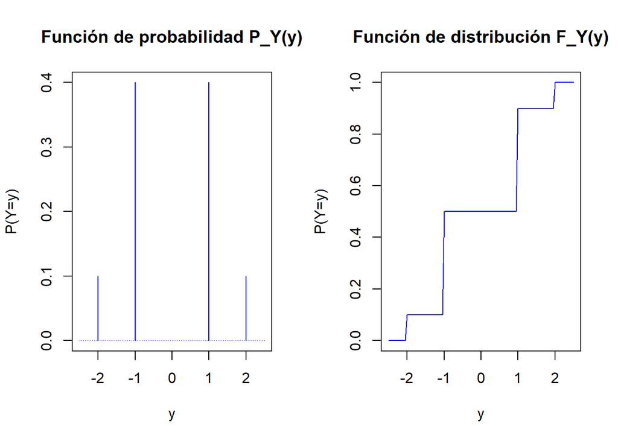

```r
par(mfrow=c(1,2))
plot(P_Y,col="blue",from=-2.5,to=2.5,
      ylab="P(Y=y)",xlab="y",type='h',
      main="Función de probabilidad P_Y(y)")

plot(F_Y,col="blue",from=-2.5,to=2.5,
      ylab="P(Y=y)",xlab="y",
      main="Función de distribución F_Y(y)")
```

```r
par(mfrow=c(1,1))
```

## Problema 3

Tenemos un dado, bien equilibrado, de doce caras numeradas del 1 al 12 ([dodecaedro dados de rol](https://es.wikipedia.org/wiki/Dados_de_rol)).

1. Calcular la función de probabilidad de la variables $X=$ número de la cara superior del dado en un lanzamiento, calcular E(X) y $Var(X)$.
2. Calcular la función de distribución de $X$ y el cuantil $0.4$ que para una variable aleatoria discreta es el primer valor $x_{0.4}$ del dominio de $X$ tal que $P(X\leq x_{0.4})\geq 0.4$.
3. Si $Y$ es al v.a. que cuenta el número de veces que tiramos el dado hasta obtener el primer $5$ calcular la función de distribución de $Y$.

### Solución

**Apartado 1**

$$P_X(x)=P(X=x)=\left\{\begin{array}{ll}
\frac1{12} & \mbox{, si } x=1,2,3,\ldots,11,12,
\\
0 & \mbox{ en otro caso}.
\end{array}\right.$$
El dominio de $X$ es $D_X=\{x\in \mathbb{R} | P_X(x)=P(X=x)>0\}=\{1,2,\ldots 12\}$

**Apartado 2**

$$F_X(x)=P(X\leq x)=
\left\{\begin{array}{ll}
0 & \mbox{, si } x< 1,\\
\frac{k}{12}& \mbox{, si } k \leq x < k+1 \mbox{ para }
k=1,2,\ldots,11\\
1 & \mbox{, si } 12\leq x.
\end{array}\right.$$

```r
distribucion=c(1:12)/12
distribucion
```

```
##  [1] 0.08333333 0.16666667 0.25000000 0.33333333 0.41666667 0.50000000
##  [7] 0.58333333 0.66666667 0.75000000 0.83333333 0.91666667 1.00000000
```

```r
which(distribucion>=0.4)
```

```
## [1]  5  6  7  8  9 10 11 12
```

```r
which(distribucion>=0.4)[1]
```

```
## [1] 5
```

```r
distribucion[which(distribucion>=0.4)]
```

```
## [1] 0.4166667 0.5000000 0.5833333 0.6666667 0.7500000 0.8333333 0.9166667
## [8] 1.0000000
```

```r
distribucion[which(distribucion>=0.4)][1]
```

```
## [1] 0.4166667
```

Como se ve en $P(X\leq 5)=\frac{5}{12}=0.4166667>0.4$ luego $x_{0.4}=5$ pues es el primer valor del dominio de $X$ que cumple la condición $P(X\leq x_{0.4})\geq 0.4$.

$$\mu_X=E(X)=\displaystyle\sum_{x=1}^{12}
x\cdot P_X(x)=\sum_{x=1}^{12} x\cdot \frac{1}{12}=
\frac{1}{12}\sum_{x=1}^{12} x=\frac{1}{12}\cdot
\frac{12\cdot(12+1)}{2}=6.5.$$

Ahora calculamos la esperanza de $X^2$.

$$E(X^2)=\displaystyle\sum_{x=1}^{12}
x^2\cdot P_X(x)=\sum_{x=1}^{12} x^2\cdot \frac{1}{12}=
\frac{1}{12}\sum_{x=1}^{12} x^2=\frac{1}{12}\cdot
\frac{12\cdot(12+1)\cdot (2\cdot 12+1)}{6}=\frac{13\cdot25}{6}=54.16667.$$

Con los dos últimos resultados podemos calcular la varianza de $X$

$$\sigma_X^2=Var(X)=E(X^2)-E(X)^2=54.16667-6.5^2=11.91667.$$
La desviación típica de $X$ es $\sigma_X=+\sqrt{Var(x)}=+\sqrt{11.91667}=3.452053$

## Problema 4

Consideremos la v.a. continua $X$ que tiene por función de densidad para a alguna constante $\alpha\in \mathbb{R}$:

$$f_X (t)=
\left\{\begin{array}{ll}
\alpha \cdot t^4, & \mbox{si } -1 < t <1,
\\
0 & \mbox{ en otro caso}.
\end{array}\right.$$

1. Calculad $\alpha$ para que $f_X$ sea densidad y especificad su dominio $D_X$.
2. Calculad la función de distribución de la v.a. $X$; $F_X(x)=P(X\leq x)$.
3. Calculad $E(X)$ y $Var(X)$.
4. Calcula en cuantil $0.9$ de $X$ que, para v.a. continuas, es el primer valor de $x_{0.95}$ tal que $P(X\leq x_{0.95})=0.95$.

### Solución

**Apartado 1**

$1=\int_{-1}^1 \alpha\cdot t^4 dt= \left. \alpha \frac{t^5}{5} \right|_{-1}^1= \alpha\left( \frac{1^5}{5}-\frac{(-1)^5}{5} \right)=\alpha\cdot \frac25.$

luego tenemos que $\alpha=\frac52.$ y

$$f_X (t)=
\left\{\begin{array}{ll}
\frac52 \cdot t^4, & \mbox{si } -1 < t <1,
\\
0 & \mbox{ en otro caso}.
\end{array}\right.$$

**Apartado 2**

$$F_X(x)=P(X\leq x)=
\left\{\begin{array}{ll}
0 & \mbox{, si } x\leq -1\\
\displaystyle\int_{-1}^x \frac52 \cdot t^4 dt=\left[\frac52\cdot
\frac{t^5}{5}\right]_{t=-1}^{t=x}=\frac52\left(\frac{x^5}{5}+\frac15\right) &
\mbox{, si } -1 < x <1,
\\
1 & \mbox{, si } 1\leq x.
\end{array}\right.$$
$$F_X(x)=P(X\leq x)=
\left\{\begin{array}{ll}
0 & \mbox{, si } x\leq -1\\
\frac{x^5+1}{2} & \mbox{, si } -1 < x <1,
\\
1 & \mbox{, si } 1\leq x.
\end{array}\right.$$

**Apartado 3**

$$E(X)=\displaystyle\int_{-1}^1 x\frac52
\cdot x^4 dx=\int_{-1}^1 \frac52 \cdot x^5 dx
=\left[\frac52\cdot
\frac{x^6}{6}\right]_{-1}^1=\frac52\left(\frac{1}{6}-\frac{1}{6}\right)=0.$$

$$E(X^2)=\displaystyle\int_{-1}^1 x^2\cdot
\frac52 \cdot x^4 dx=
\int_{_1}^1 \frac52 \cdot x^6 dx
=\left[\frac52\cdot \frac{x^7}{7}\right]_{x=-1}^{x=1}=\frac52\cdot
\left(\frac{1}{7}+\frac17\right)=\frac57.$$

$$Var(X)=E(X^2)-E(X)^2=\frac57-0^2=\frac57.$$

**Apartado 4**

Nos piden $x_{0.9}$ el cuantil $0.9$

$$0.9=F_X(x_{0.9})=\frac{x_{0.9}^5+1}{2},$$

# Estructuras de datos

## Problema 5

Genera la matriz identidad de orden 4 y modifica sus entradas para obtener la matriz $I$.
$$I=\left( \begin{array}{cccc} 0&0&0&0
\\ 0&2&0&0 \\ 0&0&3&0 \\ 0&0&0&4
\end{array} \right)$$

### Solución

Creamos la matriz

```r
I=diag(c(1,1,1,1))
I
```

```
##      [,1] [,2] [,3] [,4]
## [1,]    1    0    0    0
## [2,]    0    1    0    0
## [3,]    0    0    1    0
## [4,]    0    0    0    1
```

```r
diag(I)=c(0,2,3,4)
I
```

```
##      [,1] [,2] [,3] [,4]
## [1,]    0    0    0    0
## [2,]    0    2    0    0
## [3,]    0    0    3    0
## [4,]    0    0    0    4
```

## Problema 6

Realizar las siguientes operaciones $A+B$, $A-B$, $3B$ y $BA^{t}$ siendo:

$$A=\left( \begin{array}{cccc}
1&2&3&0 \\ 2&4&6&0 \\ 3&6&9&0
\\ 4&8&12&0 \end{array} \right)\text{ y } B=\left(
\begin{array}{cccc} 0&2&0&0 \\ 0&0&3&0 \\
0&0&0&0 \\ 0&0&0&4 \end{array}
\right)$$

### Solución

```r
A=matrix(c(1,2,3,0,2,4,6,0,3,6,9,0,4,8,12,0),ncol=4,byrow = TRUE)
A
```

```
##      [,1] [,2] [,3] [,4]
## [1,]    1    2    3    0
## [2,]    2    4    6    0
## [3,]    3    6    9    0
## [4,]    4    8   12    0
```

```r
# La B la construimos de otra forma
B=rbind(c(0,2,0,0),c(0,0,3,0),c(0,0,0,0),c(0,0,0,4))
B
```

```
##      [,1] [,2] [,3] [,4]
## [1,]    0    2    0    0
## [2,]    0    0    3    0
## [3,]    0    0    0    0
## [4,]    0    0    0    4
```

Operamos

```r
A+B
```

```
##      [,1] [,2] [,3] [,4]
## [1,]    1    4    3    0
## [2,]    2    4    9    0
## [3,]    3    6    9    0
## [4,]    4    8   12    4
```

```r
A-B
```

```
##      [,1] [,2] [,3] [,4]
## [1,]    1    0    3    0
## [2,]    2    4    3    0
## [3,]    3    6    9    0
## [4,]    4    8   12   -4
```

```r
3*B
```

```
##      [,1] [,2] [,3] [,4]
## [1,]    0    6    0    0
## [2,]    0    0    9    0
## [3,]    0    0    0    0
## [4,]    0    0    0   12
```

```r
B%*%t(A)
```

```
##      [,1] [,2] [,3] [,4]
## [1,]    4    8   12   16
## [2,]    9   18   27   36
## [3,]    0    0    0    0
## [4,]    0    0    0    0
```

```r
#notemos que es distinto de
B*t(A)
```

```
##      [,1] [,2] [,3] [,4]
## [1,]    0    4    0    0
## [2,]    0    0   18    0
## [3,]    0    0    0    0
## [4,]    0    0    0    0
```

## Problema 7

Resolver el sistema de ecuaciones:

$$\left\{\begin{array}{llll} 3x-y+z=-1\\
9x-2y+z=-9\\ 3x+y-2z=-9 \end{array}\right.$$

### Solución

```r
A=matrix(c(3,-1,1,9,-2,1,3,1,-2),ncol=3,byrow=TRUE)
A
```

```
##      [,1] [,2] [,3]
## [1,]    3   -1    1
## [2,]    9   -2    1
## [3,]    3    1   -2
```

```r
b=matrix(c(-1,-9,-9),ncol=1)
b
```

```
##      [,1]
## [1,]   -1
## [2,]   -9
## [3,]   -9
```

```r
solve(A,b)
```

```
##      [,1]
## [1,]   -1
## [2,]    2
## [3,]    4
```

## Problema 8

1. Crea la siguiente lista:

```
$padre
[1] "juan"

$madre
[1] "maria"

$numero.hijos
[1] 3

$nombre.hijos
[1] "luis"   "carlos" "eva"

$ciudad
[1] "lugo"
```

2. Calcula el número de elementos de la lista, y el número de elementos del tercer componente.
3. Añade un nuevo componente llamado edades.hijos con las edades de los tres hijo. Las edades han de estar ordenadas de mayor a menor, y comprendidas entre los 17 y 29 años.
4. Elimina el componente numero.hijos

### Solución

**Apartado 1**

```r
lista=list(
  padre="juan",
  madre="maria",
  numero.hijos=3,
  nombre.hijos=c("luis","carlos","eva"),
  ciudad="lugo")
lista
```

```
## $padre
## [1] "juan"
##
## $madre
## [1] "maria"
##
## $numero.hijos
## [1] 3
##
## $nombre.hijos
## [1] "luis"   "carlos" "eva"
##
## $ciudad
## [1] "lugo"
```

**Apartado 2**

Número de elementos de la lista

```r
length(lista)
```

```
## [1] 5
```

```r
str(lista)
```

```
## List of 5
##  $ padre       : chr "juan"
##  $ madre       : chr "maria"
##  $ numero.hijos: num 3
##  $ nombre.hijos: chr [1:3] "luis" "carlos" "eva"
##  $ ciudad      : chr "lugo"
```

```r
names(lista)
```

```
## [1] "padre"        "madre"        "numero.hijos" "nombre.hijos" "ciudad"
```

Número de elemento del tercer componente

```r
length(lista[[3]])
```

```
## [1] 1
```

```r
lista1=lista[-3]
lista1
```

```
## $padre
## [1] "juan"
##
## $madre
## [1] "maria"
##
## $nombre.hijos
## [1] "luis"   "carlos" "eva"
##
## $ciudad
## [1] "lugo"
```

```r
# O también
lista2=lista[-which(names(lista)=="numero.hijos")]
lista2
```

```
## $padre
## [1] "juan"
##
## $madre
## [1] "maria"
##
## $nombre.hijos
## [1] "luis"   "carlos" "eva"
##
## $ciudad
## [1] "lugo"
```

**Apartado 3**

```r
lista$edades.hijos=c(17,20,29)
lista
```

```
## $padre
## [1] "juan"
##
## $madre
## [1] "maria"
##
## $numero.hijos
## [1] 3
##
## $nombre.hijos
## [1] "luis"   "carlos" "eva"
##
## $ciudad
## [1] "lugo"
##
## $edades.hijos
## [1] 17 20 29
```

```r
lista$edades.hijos
```

```
## [1] 17 20 29
```